# Example Report Template for a Data Analysis Project

The structure below is one possible setup for a report stemming from a data analysis project. It loosely follows the structure of a standard scientific manuscript. Adjust as needed. You don’t need to have exactly these sections, but the content covering those sections should be addressed.

This uses [HTML as output format](https://quarto.org/docs/output-formats/html-basics.html). See [the Quarto documentation](https://quarto.org/) for instructions on how to use other formats.

**Authors**

- Esther Palmer$^{1,2,*}$
- Katherine Lorusso$^{3, *}$

**Author affiliations**

1. Departmet of Microbiology, University of Georgia, Athens, GA, USA.
2. Department of Population Health, University of Georgia, GA, USA.
3. University of Georgia.

$*$ These authors contributed equally to this work.

$\land$ Corresponding author: some@email.com

$\dagger$ Disclaimer: The opinions expressed in this article are the author’s own and don’t reflect their employer.

# 1 Summary

This project was part of an exercise for the MADA course to learn about data cleaning and the READY workflow.

# 2 Methods

*Describe your methods. That should describe the data, the cleaning processes, and the analysis approaches. You might want to provide a shorter description here and all the details in the supplement.*

Data included height, weight, gender, pets owned, and number of books read in the last year. Data was cleaned by removing individuals from the set with missing data. Various plots and tables were made to explore the data. Data was eventually fit to a linear model for final analysis.

## 2.1 Data acquisition

Data was made up by Esther Palmer in order to have something for this exercise.

## 2.2 Data import and cleaning

Packages used:

```r
library(readxl) #for loading Excel files
library(dplyr) #for data processing/cleaning
library(tidyr) #for data processing/cleaning
library(skimr) #for nice visualization of data
library(here) #to set paths
```

Load data

```r
data_location <- here::here("data","raw-data","exampledata2.xlsx")
rawdata <- readxl::read_excel(data_location)
codebook <- readxl::read_excel(data_location, sheet ="Codebook")
```

Clean Data

```r
d1 <- rawdata %>% dplyr::filter( Height != "sixty" ) %>%
                  dplyr::mutate(Height = as.numeric(Height))

skimr::skim(d1)
```

Data summary

| Name | d1 |
| --- | --- |
| Number of rows | 13 |
| Number of columns | 5 |
| _______________________ |  |
| Column type frequency: |  |
| character | 2 |
| numeric | 3 |
| ________________________ |  |
| Group variables | None |

**Variable type: character**

| skim_variable | n_missing | complete_rate | min | max | empty | n_unique | whitespace |
| --- | --- | --- | --- | --- | --- | --- | --- |
| Gender | 0 | 1 | 1 | 2 | 0 | 5 | 0 |
| Pets_owned | 0 | 1 | 3 | 6 | 0 | 3 | 0 |

**Variable type: numeric**

| skim_variable | n_missing | complete_rate | mean | sd | p0 | p25 | p50 | p75 | p100 | hist |
| --- | --- | --- | --- | --- | --- | --- | --- | --- | --- | --- |
| Height | 0 | 1.00 | 151.62 | 46.46 | 6 | 154.00 | 165 | 175 | 192 | ▁▁▁▂▇ |
| Weight | 1 | 0.92 | 647.92 | 2000.48 | 45 | 54.75 | 73 | 90 | 7000 | ▇▁▁▁▁ |
| Number_books_read | 0 | 1.00 | 8.15 | 10.84 | 0 | 1.00 | 3 | 11 | 32 | ▇▁▁▂▁ |

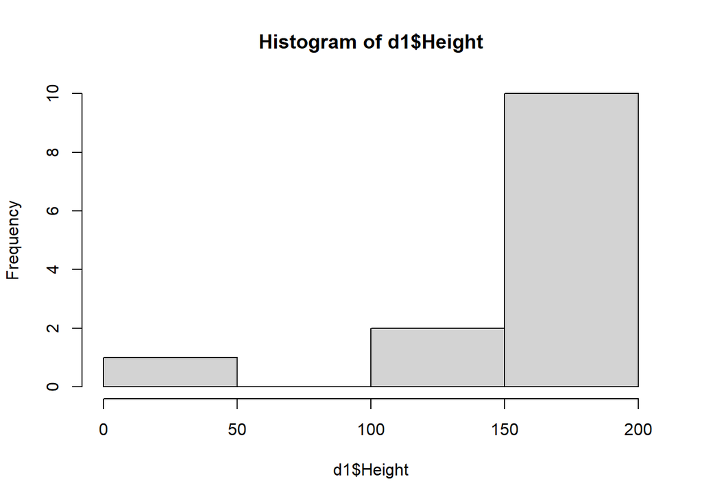

```r
hist(d1$Height)
```

```r
d2 <- d1 %>% dplyr::mutate( Height = replace(Height, Height=="6",round(6*30.48,0)) )
skimr::skim(d2)
```

Data summary

| Name | d2 |
| --- | --- |
| Number of rows | 13 |
| Number of columns | 5 |
| _______________________ |  |
| Column type frequency: |  |
| character | 2 |
| numeric | 3 |
| ________________________ |  |
| Group variables | None |

**Variable type: character**

| skim_variable | n_missing | complete_rate | min | max | empty | n_unique | whitespace |
| --- | --- | --- | --- | --- | --- | --- | --- |
| Gender | 0 | 1 | 1 | 2 | 0 | 5 | 0 |
| Pets_owned | 0 | 1 | 3 | 6 | 0 | 3 | 0 |

**Variable type: numeric**

| skim_variable | n_missing | complete_rate | mean | sd | p0 | p25 | p50 | p75 | p100 | hist |
| --- | --- | --- | --- | --- | --- | --- | --- | --- | --- | --- |
| Height | 0 | 1.00 | 165.23 | 16.52 | 133 | 155.00 | 166 | 178 | 192 | ▂▇▆▆▃ |
| Weight | 1 | 0.92 | 647.92 | 2000.48 | 45 | 54.75 | 73 | 90 | 7000 | ▇▁▁▁▁ |
| Number_books_read | 0 | 1.00 | 8.15 | 10.84 | 0 | 1.00 | 3 | 11 | 32 | ▇▁▁▂▁ |

```r
d3 <- d2 %>%  dplyr::filter(Weight != 7000) %>% tidyr::drop_na()
skimr::skim(d3)
```

Data summary

| Name | d3 |
| --- | --- |
| Number of rows | 11 |
| Number of columns | 5 |
| _______________________ |  |
| Column type frequency: |  |
| character | 2 |
| numeric | 3 |
| ________________________ |  |
| Group variables | None |

**Variable type: character**

| skim_variable | n_missing | complete_rate | min | max | empty | n_unique | whitespace |
| --- | --- | --- | --- | --- | --- | --- | --- |
| Gender | 0 | 1 | 1 | 2 | 0 | 5 | 0 |
| Pets_owned | 0 | 1 | 3 | 6 | 0 | 3 | 0 |

**Variable type: numeric**

| skim_variable | n_missing | complete_rate | mean | sd | p0 | p25 | p50 | p75 | p100 | hist |
| --- | --- | --- | --- | --- | --- | --- | --- | --- | --- | --- |
| Height | 0 | 1 | 167.09 | 16.81 | 133 | 155.5 | 166 | 179.0 | 192 | ▂▇▅▇▅ |
| Weight | 0 | 1 | 70.45 | 20.65 | 45 | 54.5 | 70 | 85.0 | 110 | ▇▂▃▃▂ |
| Number_books_read | 0 | 1 | 7.36 | 10.26 | 0 | 1.5 | 3 | 8.5 | 32 | ▇▁▁▁▁ |

```r
d3$Gender <- as.factor(d3$Gender)
skimr::skim(d3)
```

Data summary

| Name | d3 |
| --- | --- |
| Number of rows | 11 |
| Number of columns | 5 |
| _______________________ |  |
| Column type frequency: |  |
| character | 1 |
| factor | 1 |
| numeric | 3 |
| ________________________ |  |
| Group variables | None |

**Variable type: character**

| skim_variable | n_missing | complete_rate | min | max | empty | n_unique | whitespace |
| --- | --- | --- | --- | --- | --- | --- | --- |
| Pets_owned | 0 | 1 | 3 | 6 | 0 | 3 | 0 |

**Variable type: factor**

| skim_variable | n_missing | complete_rate | ordered | n_unique | top_counts |
| --- | --- | --- | --- | --- | --- |
| Gender | 0 | 1 | FALSE | 5 | M: 4, F: 3, O: 2, N: 1 |

**Variable type: numeric**

| skim_variable | n_missing | complete_rate | mean | sd | p0 | p25 | p50 | p75 | p100 | hist |
| --- | --- | --- | --- | --- | --- | --- | --- | --- | --- | --- |
| Height | 0 | 1 | 167.09 | 16.81 | 133 | 155.5 | 166 | 179.0 | 192 | ▂▇▅▇▅ |
| Weight | 0 | 1 | 70.45 | 20.65 | 45 | 54.5 | 70 | 85.0 | 110 | ▇▂▃▃▂ |
| Number_books_read | 0 | 1 | 7.36 | 10.26 | 0 | 1.5 | 3 | 8.5 | 32 | ▇▁▁▁▁ |

```r
d3$Pets_owned <- as.factor(d3$Pets_owned)
skimr::skim(d3)
```

Data summary

| Name | d3 |
| --- | --- |
| Number of rows | 11 |
| Number of columns | 5 |
| _______________________ |  |
| Column type frequency: |  |
| factor | 2 |
| numeric | 3 |
| ________________________ |  |
| Group variables | None |

**Variable type: factor**

| skim_variable | n_missing | complete_rate | ordered | n_unique | top_counts |
| --- | --- | --- | --- | --- | --- |
| Gender | 0 | 1 | FALSE | 5 | M: 4, F: 3, O: 2, N: 1 |
| Pets_owned | 0 | 1 | FALSE | 3 | Cat: 5, Dog: 5, Liz: 1 |

**Variable type: numeric**

| skim_variable | n_missing | complete_rate | mean | sd | p0 | p25 | p50 | p75 | p100 | hist |
| --- | --- | --- | --- | --- | --- | --- | --- | --- | --- | --- |
| Height | 0 | 1 | 167.09 | 16.81 | 133 | 155.5 | 166 | 179.0 | 192 | ▂▇▅▇▅ |
| Weight | 0 | 1 | 70.45 | 20.65 | 45 | 54.5 | 70 | 85.0 | 110 | ▇▂▃▃▂ |
| Number_books_read | 0 | 1 | 7.36 | 10.26 | 0 | 1.5 | 3 | 8.5 | 32 | ▇▁▁▁▁ |

```r
d4 <- d3 %>% dplyr::filter( !(Gender %in% c("NA","N")) ) %>% droplevels()
skimr::skim(d4)
```

Data summary

| Name | d4 |
| --- | --- |
| Number of rows | 9 |
| Number of columns | 5 |
| _______________________ |  |
| Column type frequency: |  |
| factor | 2 |
| numeric | 3 |
| ________________________ |  |
| Group variables | None |

**Variable type: factor**

| skim_variable | n_missing | complete_rate | ordered | n_unique | top_counts |
| --- | --- | --- | --- | --- | --- |
| Gender | 0 | 1 | FALSE | 3 | M: 4, F: 3, O: 2 |
| Pets_owned | 0 | 1 | FALSE | 3 | Cat: 4, Dog: 4, Liz: 1 |

**Variable type: numeric**

| skim_variable | n_missing | complete_rate | mean | sd | p0 | p25 | p50 | p75 | p100 | hist |
| --- | --- | --- | --- | --- | --- | --- | --- | --- | --- | --- |
| Height | 0 | 1 | 165.67 | 15.98 | 133 | 156 | 166 | 178 | 183 | ▂▁▃▃▇ |
| Weight | 0 | 1 | 70.11 | 21.25 | 45 | 55 | 70 | 80 | 110 | ▇▂▃▂▂ |
| Number_books_read | 0 | 1 | 7.78 | 11.09 | 0 | 2 | 3 | 6 | 32 | ▇▁▁▁▁ |

```r
processeddata2 <- d4

save_data_location <- here::here("data","processed-data","processeddata2.rds")
saveRDS(processeddata2, file = save_data_location)
```

# 3 Results

## 3.1 Exploratory/Descriptive analysis

*Use a combination of text/tables/figures to explore and describe your data. Show the most important descriptive results here. Additional ones should go in the supplement. Even more can be in the R and Quarto files that are part of your project.*

Table 1 shows a summary of the data.

Note the loading of the data providing a **relative** path using the `../../` notation. (Two dots means a folder up). You never want to specify an **absolute** path like `C:\yourname\yourproject\results\` because if you share this with someone, it won’t work for them since they don’t have that path. You can also use the `here` R package to create paths. See examples of that below. I generally recommend the `here` package.

Table 1: Data summary table. All caption text goes here.

| skim_type | skim_variable | n_missing | complete_rate | character.min | character.max | character.empty | character.n_unique | character.whitespace | factor.ordered | factor.n_unique | factor.top_counts | numeric.mean | numeric.sd | numeric.p0 | numeric.p25 | numeric.p50 | numeric.p75 | numeric.p100 | numeric.hist |
| --- | --- | --- | --- | --- | --- | --- | --- | --- | --- | --- | --- | --- | --- | --- | --- | --- | --- | --- | --- |
| character | Pets_owned | 0 | 1 | 3 | 6 | 0 | 3 | 0 | NA | NA | NA | NA | NA | NA | NA | NA | NA | NA | NA |
| factor | Gender | 0 | 1 | NA | NA | NA | NA | NA | FALSE | 3 | M: 4, F: 3, O: 2 | NA | NA | NA | NA | NA | NA | NA | NA |
| numeric | Height | 0 | 1 | NA | NA | NA | NA | NA | NA | NA | NA | 165.666667 | 15.97655 | 133 | 156 | 166 | 178 | 183 | ▂▁▃▃▇ |
| numeric | Weight | 0 | 1 | NA | NA | NA | NA | NA | NA | NA | NA | 70.111111 | 21.24526 | 45 | 55 | 70 | 80 | 110 | ▇▂▃▂▂ |
| numeric | Number_books_read | 0 | 1 | NA | NA | NA | NA | NA | NA | NA | NA | 7.777778 | 11.08803 | 0 | 2 | 3 | 6 | 32 | ▇▁▁▁▁ |

## 3.2 Basic statistical analysis

*To get some further insight into your data, if reasonable you could compute simple statistics (e.g. simple models with 1 predictor) to look for associations between your outcome(s) and each individual predictor variable. Though note that unless you pre-specified the outcome and main exposure, any “p<0.05 means statistical significance” interpretation is not valid.*

Figure 1 shows a scatterplot figure produced by one of the R scripts.

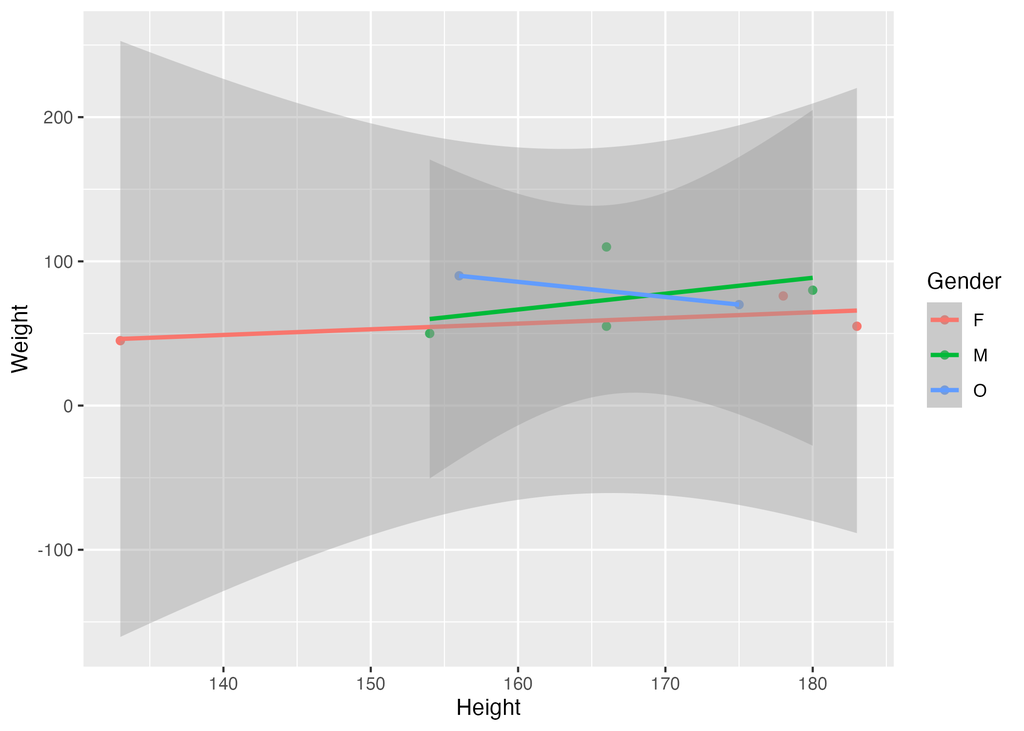

Figure 1: Height and weight stratified by gender.

## 3.3 Full analysis

*Use one or several suitable statistical/machine learning methods to analyze your data and to produce meaningful figures, tables, etc. This might again be code that is best placed in one or several separate R scripts that need to be well documented. You want the code to produce figures and data ready for display as tables, and save those. Then you load them here.*

Example Table 2 shows a summary of a linear model fit.

Table 2: Linear model fit table.

| term | estimate | std.error | statistic | p.value |
| --- | --- | --- | --- | --- |
| (Intercept) | 149.2726967 | 23.3823360 | 6.3839942 | 0.0013962 |
| Weight | 0.2623972 | 0.3512436 | 0.7470519 | 0.4886517 |
| GenderM | -2.1244913 | 15.5488953 | -0.1366329 | 0.8966520 |
| GenderO | -4.7644739 | 19.0114155 | -0.2506112 | 0.8120871 |

# 4 Discussion